# P&S-2025: Lab assignment 4

Lidiia Sokha, Oleksandr Lykhanskyi, Mariia Krasniukevych

2024-11-29

# Problem1

We test the hypotheses
$$H_0: \mu_1 = \mu_2, \qquad
H_1: \mu_1 \neq \mu_2.$$
Since the variances of both samples are known and equal to 1, the appropriate test for the equality of two means is the two-sample z-test. The two-sample z-statistic has the form:
$$Z = \frac{\bar{X} - \bar{Y}}{\sqrt{\frac{\sigma^2}{n} +
\frac{\sigma^2}{m}}}.$$
For a two-sided test with significance level $\alpha = 0.05$, the rejection region is
$$|Z| > z_{1-\alpha/2}.$$
Since
$$z_{1 - 0.05/2} = z_{0.975} \approx 1.96,$$
we reject $H_0$ if
$$|Z| > 1.96.$$
The p-value of a two-sided $Z$-test is
$$p = 2\left(1 - \Phi(|Z|)\right).$$

```r
id_number <- 37
f <- function(k, n) {
  x <- k*log(k^2 * n + pi)
  fractional_part <- x - floor(x)
  return(fractional_part)
}
all_values <- 1:150
a.data <- sapply(all_values, f, id_number)
x_k <- qnorm(a.data[1:100])
y_l <- qnorm(a.data[101:150])
n <- 100
m <- 50
sigma <- 1
x_bar <- mean(x_k)
y_bar <- mean(y_l)
Z <- (x_bar - y_bar)/(sqrt(sigma/n + sigma/m))
alpha <- 0.05
z_critical <- qnorm(1-alpha/2)
p_value <- 2*(1 - pnorm(abs(Z)))
cat("Z =", Z, "\n")
```

```
## Z = -1.054182
```

```r
cat("critical z =", z_critical, "\n")
```

```
## critical z = 1.959964
```

```r
cat("p-value =", p_value, "\n")
```

```
## p-value = 0.2917995
```

Since |Z| = 1.054182 < 1.959964, the test statistic does not fall into the rejection region. Therefore, there is no evidence to reject the null hypothesis. Because p>0.05 we again conclude that the null hypothesis should not be rejected.

# Problem2

We test the hypotheses
$$H_0: \sigma_1^2 = \sigma_2^2
\qquad \text{vs.} \qquad
H_1: \sigma_1^2 > \sigma_2^2.$$

We use the classical F-test for the equality of two variances. The test statistic is defined as
$$F = \frac{S_1^2}{S_2^2},$$
where $S_1^2$ and $S_2^2$ are the sample variances. Under the null hypothesis,
$$F \sim F_{\,n-1,\,m-1}.$$

Since the alternative is one-sided ($\sigma_1^2 > \sigma_2^2$), the rejection region is
$$F > F_{1-\alpha}(n-1, m-1).$$
$$F_{\text{crit}} = F_{0.95}(99, 49) = 1.530999.$$

The p-value is computed as
$$p = P(F_{99,49} \ge F_{\text{obs}})
= 1 - F_{F}(F_{\text{obs}}; 99,49),$$
where $F_F$ is the CDF of the F-distribution.

```r
df1 <- n - 1
df2 <- m - 1
s1_var <- var(x_k)
s2_var <- var(y_l)
f_stat <- s1_var / s2_var
alpha <- 0.05
f_critical <- qf(1 - alpha, df1, df2)
p_value <- 1 - pf(f_stat, df1, df2)
cat("F =", f_stat, "\n")
```

```
## F = 1.158672
```

```r
cat("critical f =", f_critical, "\n")
```

```
## critical f = 1.530999
```

```r
cat("p-value =", p_value, "\n")
```

```
## p-value = 0.2873654
```

Since F = 1.158672 < 1.530999 the test statistic does not fall into the rejection region. The p-value is p = 0.2873654 > 0.05, there is no evidence to reject the null hypothesis.

# Problem3

```r
#Saving data
n <- 37
k_nums <- 1:150

#Making a_function from the task
a_function <- function(k, n) {
  x <- k * log(k^2 * n + pi)
  x - floor(x)
}

#Data for observation
a_data <- a_function(k_nums, n)
x <- qnorm(a_data[1:100])
y <- qnorm(a_data[101:150])

mu_hat <- mean(x)
sigma_hat <- sd(x)

#(a)
ks_test1 <- ks.test(x, "pnorm", mean = mu_hat, sd = sigma_hat)
cat("Part (a)")
```

```
## Part (a)
```

```r
ks_test1
```

```
##
##  Asymptotic one-sample Kolmogorov-Smirnov test
##
## data:  x
## D = 0.069821, p-value = 0.7142
## alternative hypothesis: two-sided
```

```r
#(b)
lambda <- 1
ks_test2 <- ks.test(x, "pexp", rate = lambda)
cat("Part (b)")
```

```
## Part (b)
```

```r
ks_test2
```

```
##
##  Asymptotic one-sample Kolmogorov-Smirnov test
##
## data:  x
## D = 0.53293, p-value < 2.2e-16
## alternative hypothesis: two-sided
```

```r
#(c)
ks_test3 <- ks.test(x, y)
cat("Part (c)")
```

```
## Part (c)
```

```r
ks_test3
```

```
##
##  Exact two-sample Kolmogorov-Smirnov test
##
## data:  x and y
## D = 0.11, p-value = 0.8042
## alternative hypothesis: two-sided
```

## Main concept of KS test:

**The Kolmogorov-Smirnov test is a non-parametric (usually, here we have an exception in part (a)) goodness-of-fit test.**

There is two types of KS test:

- **One-sampled KS test:**

Comparing **empirical CDF** of given sample with a **theoretical CDF**

- **Two-sampled KS test**

Comparing **empirical CDF** of two given samples (in our case X and Y)

The test-statistic here is:

$D = \sup_{x} \left| F_n(x) - F(x) \right|$

which shows the biggest distance between two **CDFs.**

In a result we can say that we comparing two hypothesis:

$H_0$: two samples come from the same distribution,

$H_1$: two samples come from different distributions.

And $p$-value tells if the distance large enough to reject $H_0$.

## Explanation of the test results:

**Part(a):**

$D = 0.069821,p-value = 0.7142$

The small value of $D$ shows that distance between **empirical CDF** and **theoretical CDF** is really small.

Big value of $p-value$ shows that we don’t have enough evidence to reject $H_0$

**Part(b):**

$D=0.53293, p-value < 2.2e-16$

Big value of $D$ shows that distance between **empirical CDF** and **theoretical CDF** is too large to observe they’re from the same distribution.

Small *(close to zero)* value of $p-value$ shows that we have strong evidance to reject $H_0$

**Part(с):**

$D=0.11, p-value = 0.8042$

The small value of $D$ shows that distance between two **empirical CDFs** is really small and we can observe they’re from the same distribution.

Big value of $p-value$ shows that we don’t have enough evidence to reject $H_0$

## Here are visualizations of empirical and theoretical CDFs for all tests

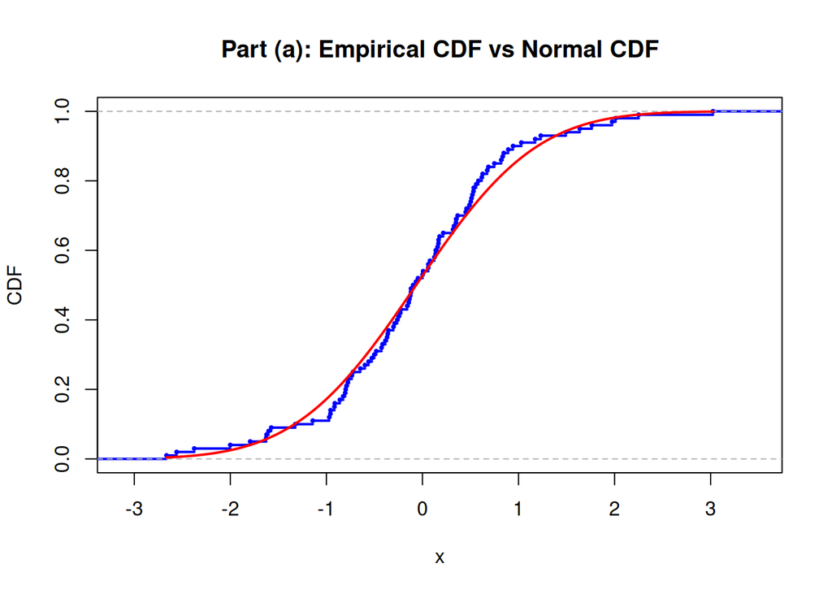

```r
Fn_x <- ecdf(x)
Fn_y <- ecdf(y)

#Part(a)
plot(Fn_x,
     main = "Part (a): Empirical CDF vs Normal CDF",
     xlab = "x",
     ylab = "CDF",
     col = "blue",
     lwd = 2,
     cex = 0.4)

xx <- seq(min(x), max(x), length.out = 500)
lines(xx, pnorm(xx, mean = mu_hat, sd = sigma_hat),
      col = "red", lwd = 2, cex = 0.4)
```

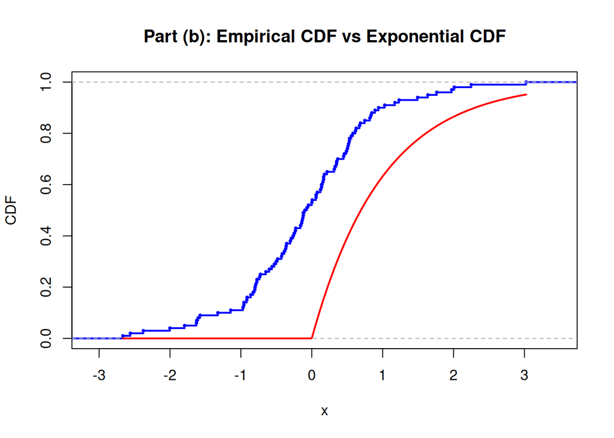

```r
#Part(b)
plot(Fn_x,
     main = "Part (b): Empirical CDF vs Exponential CDF",
     xlab = "x",
     ylab = "CDF",
     col = "blue",
     lwd = 2,
     cex = 0.4)

xx_b <- seq(min(x), max(x), length.out = 500)
lines(xx_b, pexp(xx_b, rate = lambda),
      col = "red", lwd = 2, cex = 0.4)
```

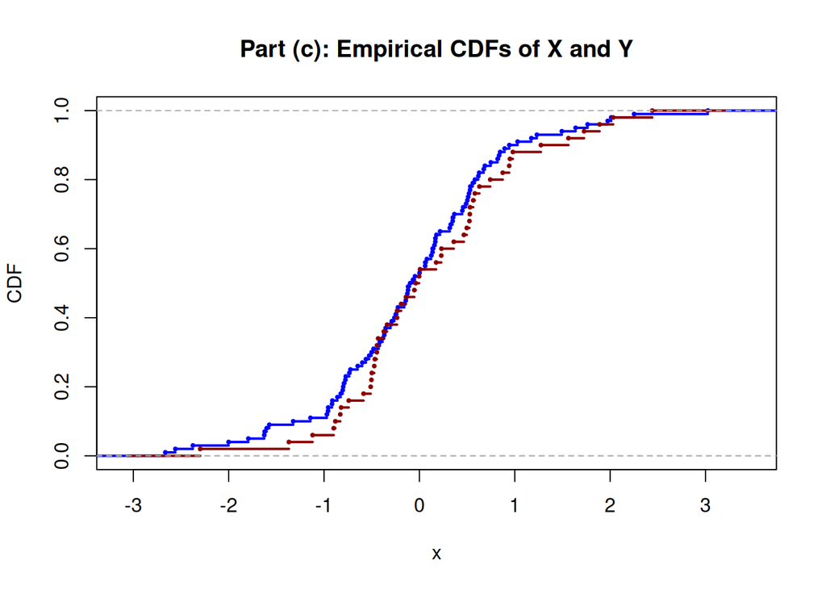

```r
#Part(c)
plot(Fn_x,
     main = "Part (c): Empirical CDFs of X and Y",
     xlab = "x",
     ylab = "CDF",
     col = "blue",
     lwd = 2,
     cex = 0.4)

lines(Fn_y, col = "darkred", lwd = 2, cex = 0.4)
```

# Problem 4

```r
# Load required libraries
library(ggplot2)  # For creating plots

# Read data from CSV file
data <- read.csv("data.csv")

# View data structure
print("Data structure:")
```

```
## [1] "Data structure:"
```

```r
print(head(data))
```

```
##   time_study  Marks
## 1      4.508 19.202
## 2      0.096  7.734
## 3      3.133 13.811
## 4      7.909 53.018
## 5      7.811 55.299
## 6      3.211 17.822
```

```r
print(summary(data))
```

```
##    time_study        Marks
##  Min.   :0.096   Min.   : 5.609
##  1st Qu.:2.058   1st Qu.:12.633
##  Median :4.022   Median :20.059
##  Mean   :4.077   Mean   :24.418
##  3rd Qu.:6.179   3rd Qu.:36.676
##  Max.   :7.957   Max.   :55.299
```

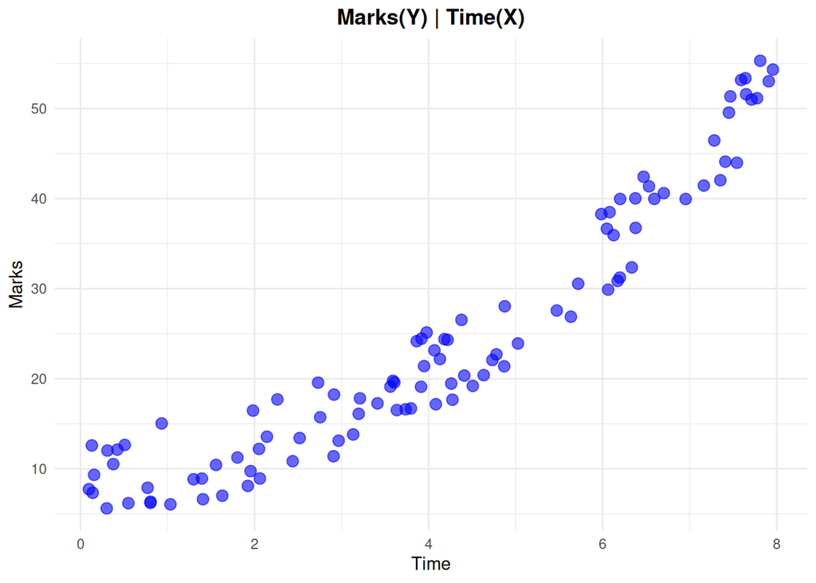

```r
# (a)
scatter_plot <- ggplot(data, aes(x = time_study, y = Marks)) + geom_point(color = "blue", size = 3, alpha = 0.6) +  # Data points

  labs(title = "Marks(Y) | Time(X)", x = "Time", y = "Marks") +
  theme_minimal() +
  theme(plot.title = element_text(hjust = 0.5, face = "bold"))

print(scatter_plot)
```

```r
#The plot shows a positive linear relationship between study time and marks
#The more a student studies, the higher their marks tend to be

# b)
# To derive coefficients we will use Least Square Method
X <- data$time_study  # Independent variable
Y <- data$Marks       # Dependent variable
n <- length(X)        # Sample size

cat(sprintf("Sample size: n = %d\n\n", n))
```

```
## Sample size: n = 100
```

```r
# Calculate means
mean_X <- mean(X)
mean_Y <- mean(Y)
cat(sprintf("Mean of X (study time): %.3f hours\n", mean_X))
```

```
## Mean of X (study time): 4.077 hours
```

```r
cat(sprintf("Mean of Y (marks): %.3f points\n\n", mean_Y))
```

```
## Mean of Y (marks): 24.418 points
```

```r
# Calculate sums needed for formulas
S_XY <- sum((X - mean_X) * (Y - mean_Y))
S_XX <- sum((X - mean_X)^2)

cat(sprintf("Σ[(Xi - X̄)(Yi - Ȳ)] = %.3f\n", S_XY))
```

```
## Σ[(Xi - X̄)(Yi - Ȳ)] = 3171.145
```

```r
cat(sprintf("Σ[(Xi - X̄)²] = %.3f\n\n", S_XX))
```

```
## Σ[(Xi - X̄)²] = 557.441
```

```r
# b = Σ[(Xi - X̄)(Yi - Ȳ)] / Σ[(Xi - X̄)²]
b <- S_XY / S_XX

cat("LEAST SQUARES FORMULA FOR SLOPE (b):\n")
```

```
## LEAST SQUARES FORMULA FOR SLOPE (b):
```

```r
cat("b = Σ[(Xi - X̄)(Yi - Ȳ)] / Σ[(Xi - X̄)²]\n")
```

```
## b = Σ[(Xi - X̄)(Yi - Ȳ)] / Σ[(Xi - X̄)²]
```

```r
cat(sprintf("b = %.3f / %.3f = %.3f\n\n", S_XY, S_XX, b))
```

```
## b = 3171.145 / 557.441 = 5.689
```

```r
# Calculate a (intercept) using formula
# a = Ȳ - b * X
a <- mean_Y - b * mean_X

cat(sprintf("a = %.3f - %.3f * %.3f = %.3f\n\n", mean_Y, b, mean_X, a))
```

```
## a = 24.418 - 5.689 * 4.077 = 1.224
```

```r
cat(sprintf("Marks = %.3f + %.3f * time_study\n", a, b))
```

```
## Marks = 1.224 + 5.689 * time_study
```

```r
# Verify with R's built-in lm() function
cat("Verification using R's lm() function:\n")
```

```
## Verification using R's lm() function:
```

```r
model <- lm(Marks ~ time_study, data = data)
print(summary(model))
```

```
##
## Call:
## lm(formula = Marks ~ time_study, data = data)
##
## Residuals:
##    Min     1Q Median     3Q    Max
## -7.866 -4.034 -0.384  2.979 10.628
##
## Coefficients:
##             Estimate Std. Error t value Pr(>|t|)
## (Intercept)   1.2239     0.9623   1.272    0.206
## time_study    5.6888     0.2042  27.853   <2e-16 ***
## ---
## Signif. codes:  0 '***' 0.001 '**' 0.01 '*' 0.05 '.' 0.1 ' ' 1
##
## Residual standard error: 4.822 on 98 degrees of freedom
## Multiple R-squared:  0.8878, Adjusted R-squared:  0.8867
## F-statistic: 775.8 on 1 and 98 DF,  p-value: < 2.2e-16
```

```r
a_lm <- coef(model)[1]
b_lm <- coef(model)[2]

cat(sprintf("Manual calculation:  a = %.6f, b = %.6f\n", a, b))
```

```
## Manual calculation:  a = 1.223858, b = 5.688750
```

```r
cat(sprintf("R's lm() function:   a = %.6f, b = %.6f\n", a_lm, b_lm))
```

```
## R's lm() function:   a = 1.223858, b = 5.688750
```

```r
cat(sprintf("b = %.3f: Each additional hour of study increases marks by %.3f points\n", b_lm, b_lm))
```

```
## b = 5.689: Each additional hour of study increases marks by 5.689 points
```

```r
cat(sprintf("a = %.3f: Expected marks with 0 hours of study (baseline)\n\n", a_lm))
```

```
## a = 1.224: Expected marks with 0 hours of study (baseline)
```

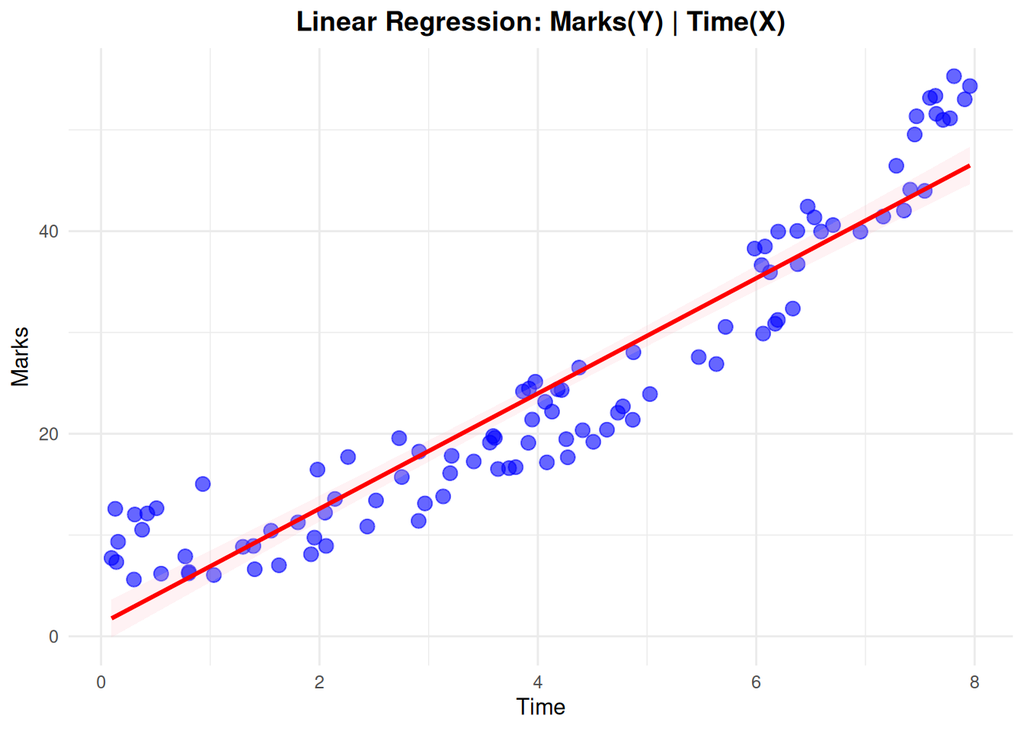

```r
regression_plot <- ggplot(data, aes(x = time_study, y = Marks)) +
  geom_point(color = "blue", size = 3, alpha = 0.6) +
  geom_smooth(method = "lm", se = TRUE, color = "red", fill = "pink", alpha = 0.2) +
  labs(
    title = "Linear Regression: Marks(Y) | Time(X)",
    x = "Time",
    y = "Marks"
  ) +
  theme_minimal() +
  theme(plot.title = element_text(hjust = 0.5, face = "bold"))

print(regression_plot)
```

```r
# c)

# R-squared (coefficient of determination)
r_squared <- summary(model)$r.squared
adj_r_squared <- summary(model)$adj.r.squared

cat(sprintf("R² = %.4f\n", r_squared))
```

```
## R² = 0.8878
```

```r
cat(sprintf("Adjusted R² = %.4f\n", adj_r_squared))
```

```
## Adjusted R² = 0.8867
```

```r
cat(sprintf("%.2f%% of variation in marks is explained by study time\n\n", r_squared * 100))
```

```
## 88.78% of variation in marks is explained by study time
```

```r
# Residual Standard Error
rse <- summary(model)$sigma
cat(sprintf("Residual Standard Error (RSE) = %.3f\n", rse))
```

```
## Residual Standard Error (RSE) = 4.822
```

```r
cat("RSE shows the typical deviation of actual values from predicted values\n\n")
```

```
## RSE shows the typical deviation of actual values from predicted values
```

```r
# Residual analysis
residuals <- residuals(model)
cat("Residuals statistics:\n")
```

```
## Residuals statistics:
```

```r
cat(sprintf("Mean of residuals: %.6f \n", mean(residuals)))
```

```
## Mean of residuals: -0.000000
```

```r
# As we can see the mean of residuals is 0, as it should be
cat(sprintf("Standard deviation of residuals: %.3f\n\n", sd(residuals)))
```

```
## Standard deviation of residuals: 4.798
```

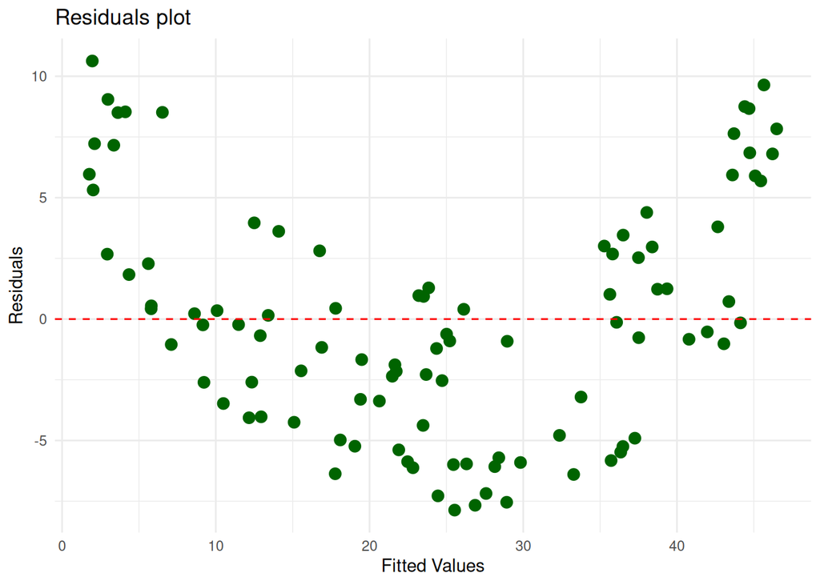

```r
# Residual plot
residual_plot <- ggplot(data.frame(fitted = fitted(model), residuals = residuals),
                        aes(x = fitted, y = residuals)) +
  geom_point(color = "darkgreen", size = 3) +
  geom_hline(yintercept = 0, linetype = "dashed", color = "red") +
  labs(
    title = "Residuals plot",
    x = "Fitted Values",
    y = "Residuals"
  ) +
  theme_minimal()

print(residual_plot)
```

```r
# d)

cat("Hypotheses:\n")
```

```
## Hypotheses:
```

```r
cat("H₀: b = 0 (Time spent studying does NOT affect marks)\n")
```

```
## H₀: b = 0 (Time spent studying does NOT affect marks)
```

```r
cat("H₁: b ≠ 0 (Time spent studying DOES affect marks)\n\n")
```

```
## H₁: b ≠ 0 (Time spent studying DOES affect marks)
```

```r
# t-statistic
t_val <- summary(model)$coefficients[2, 3]  # t-value
p_val <- summary(model)$coefficients[2, 4]  # p-value
deg_of_freedom <- model$df.residual  # Degrees of freedom

cat(sprintf("t-statistic = %.4f\n", t_val))
```

```
## t-statistic = 27.8527
```

```r
cat(sprintf("Degrees of freedom = %d\n", deg_of_freedom))
```

```
## Degrees of freedom = 98
```

```r
cat(sprintf("p-value = %.6f\n\n", p_val))
```

```
## p-value = 0.000000
```

```r
# Critical value at α = 0.05
alpha <- 0.05
t_crit <- qt(1 - alpha/2, deg_of_freedom)
cat(sprintf("Critical value t at α = 0.05: ±%.4f\n\n", t_crit))
```

```
## Critical value t at α = 0.05: ±1.9845
```

```r
# Conclusion
cat(sprintf("p-value (%.6f) < α (%.2f)\n", p_val, alpha))
```

```
## p-value (0.000000) < α (0.05)
```

```r
cat("We reject H₀. Study time is a significant predictor of marks.\n")
```

```
## We reject H₀. Study time is a significant predictor of marks.
```

```r
cat(sprintf("Additional hour of study increases marks by %.3f points.\n\n", b_lm))
```

```
## Additional hour of study increases marks by 5.689 points.
```

```r
# e)

alice_study_time <- 8
alice_prediction <- predict(model, newdata = data.frame(time_study = alice_study_time), interval = "prediction", level = 0.95)

# Alice studying for 8 hours will result in:
cat(alice_prediction[1])
```

```
## 46.73386
```

```r
# f)

# 1. Increasing sample size will lead to more accurate results
# 2. Adding other predictors would also lead to more accurate results.
# 3. It might be a good idea to look for a non-linear relationships. The resulting model might give more accurate predictions.
```